# COD Reproducibility Report

#### Methods summary:

The authors are interested in the “endowment effect” in three-to-four-year-olds. Specifically, they examine the change in subject valuation (herafter, “value change”) of two identical objects which differ in their owner (child vs. experimenter). They predict an interaction of object-owner with a priming manipulation which focuses the child on her/hisself (vs. focusing on others vs. neural control). When children are given a distractor task (between the two valuations) that makes them focus on themselves (by drawing a picture of themselves), they will display a greater endowement effect.

#### Target outcomes:

Information about the statistical model (Section 2.2.1):

> To examine the effects of priming on value-change for the two identical endowment toys, a mixed ANCOVA was conducted. Toy owner (child or experimenter) was entered as a repeated measures factor and picture type (self-focus, other- focus, neutral-focus) and gender were entered as a between sub- jects factors. Additionally, child age was normalized and entered as a covariate into the model.

Main results (Section 2.3):

> We found a significant interaction between picture construction condition and toy owner (F(2, 53) = 4.83, p = 0.01, View the MathML source). Specifically, following self-focus, children increased the value of their own toy (M = 0.95, 95% CI = [0.38, 1.52]) but not the experimenter’s toy (M = −0.07, 95% CI = [−0.74, 0.59], t(19) = 3.56, p = 0.01, d = 0.81, Bonferroni corrected). The opposite pattern of responses were observed in the other-focus condition, in which children valued the experimenter’s toy higher (M = 0.86, 95% CI = [0.20, 1.51]), but not their own toy (M = 0.17, 95% CI = [−0.39, 0.73]) - although this effect was not statistically significant (t(19) = −1.61, p = 0.36, d = 0.48, Bonferroni corrected). There was no significant effect of toy owner in the neutral-focus condition (Mchild = 0.89, 95% CIchild = [0.31, 1.46], Mexperimenter = 0.71, 95% CIexperimenter = [0.04, 1.38], t(19) = 0.48, p = 0.64, d = 0.13). The mean value change scores for each condition as a function of toy owner are presented in Fig. 2. We found no significant main effects of types of picture type (Mself = 0.44, 95% CIself = [−0.04, 0.91], Mother = 0.51, 95% CIother = [0.04, 0.98], Mneutral = 0.80, 95% CIneutral = [0.32, 1.28], F(2, 53) = 0.61, p = 0.55, View the MathML source) or toy owner (Mchild = 0.67, 95% CIchild = [0.34, 0.99], Mexperimenter = 0.50, 95% CIexperimenter = [0.12, 0.89], F(1, 53) = 0.55, p = 0.46, View the MathML source). A significant effect of age was observed (F(1, 53) = 7.68, p = 0.01, View the MathML source), indicating that older children increased their valuations more than younger children regardless of toy owner or picture condition. No significant effect of gender (F(1, 53) = 0.46, p = 0.50, View the MathML source), and no significant interactions involving gender or age were observed (Fs < 2.69, ps > 0.11, etc.).

## Step 1: Load packages

```r
library(tidyverse) # for data munging
library(knitr) # for kable table formating
#library(haven) # import and export 'SPSS', 'Stata' and 'SAS' Files
library(readxl) # import excel files
library(CODreports) # custom report functions
library(ez)

to.n <- function(fctr){
  return(as.numeric(as.character(fctr)))
}
```

## Step 2: Load data

```r
df <- read.csv("data/data.csv")
```

This data frame has 18 variables: - participant ID, gender, age, experiment #, prime_type (manipulation), - baseline scores for the endowment object(s) (reported in text to be the same for the identical objects for all children), neutral objects, - post scores for the endowment object given to the child, experimenter, and for the neutral object - prime_time is the amount of time spent on the priming / distractor task - pronouns is number of pronouns of either second person (You, for self-priming) and third person (They, for other priming) in their respective conditions - I’m not sure what “swap” is - change scores (post - baseline)

## Step 3: Tidy data

```r
df.tidy <- df %>% filter(study == 1) %>%
  separate(prime_time, into =c('min', 'sec'), sep = "min") %>%
  select(-unowned_post, -unowned_change) %>% # not used in expt 1
  separate(age, into = c("year", "month"), sep = "y") %>%
  mutate(sec = gsub("sec", "", sec),
         sec = as.numeric(sec),
         min = as.numeric(min),
         month = as.numeric(gsub("m", "", month)),
         year = as.numeric(year),
         age_in_months = year*12 + month,
         prime_time_seconds = min*60 + sec,
         neutral_baseline = to.n(neutral_baseline),
         experimenter_post = to.n(experimenter_post),
         neutral_post = to.n(neutral_post),
         experimenter_change = to.n(experimenter_change),
         neutral_change = to.n(neutral_change),
         child_baseline = endowment_baseline, # since endowment baseline is the same for both what will become the child's and the experimenter's toys, i create new variables representing this
         experimenter_baseline = endowment_baseline) %>%
  select(-endowment_baseline) %>%
  gather(object, response, ends_with("_baseline"), ends_with("_post"), ends_with("_change")) %>%
  separate(object, into = c("object", "scoringPeriod"))
```

Check the “raw” change scores by subtracting baseline from post

```r
df.tidy %>%
  spread(scoringPeriod, response) %>%
  mutate(derivedChange = post - baseline,
         diff = change - derivedChange) %>%
  summarize(totalDeviation = sum(diff))
```

```
##   totalDeviation
## 1              0
```

The “change” scores reported in the raw data are the same as “post” - “baseline”. Good.

## Step 3: Preprocessing

For ANCOVA, age is normalized

```r
mean_age = mean(df.tidy$age_in_months)
sd_age = sd(df.tidy$age_in_months)
df.tidy <- df.tidy %>%
  mutate(age_normalized = (age_in_months - mean_age) / sd_age)
```

## Step 4: Run analysis

### Descriptive statistics

```r
reported_descriptives <- list(
  self_focus = list(
    child_change =
      list( mean = 0.95, ci_low = 0.38, ci_high = 1.52),
    experimenter_change =
      list( mean = -0.07, ci_low = -0.74, ci_high = 0.59)
  ),
  other_focus = list(
    child_change =
      list( mean = 0.17, ci_low = -0.39, ci_high = 0.73),
    experimenter_change =
      list( mean = 0.86, ci_low = 0.2, ci_high = 1.51)
  ),
  neutral_focus = list(
    child_change =
      list( mean = 0.89, ci_low = 0.31, ci_high = 1.46),
    experimenter_change =
      list( mean = 0.71, ci_low = 0.04, ci_high = 1.38)
  ),
  picture_types = list(
    self =
     list(mean = 0.44, ci_low = -0.04, ci_high = 0.91),
   other =
     list(mean = 0.51, ci_low = 0.04, ci_high = 0.98),
   neutral =
     list(mean = 0.80, ci_low = 0.32, ci_high = 1.28)
   ),
  toy_owner = list(
    child = list(mean = 0.67, ci_low = 0.34, ci_high = 0.99),
    experimenter = list(mean = 0.5, ci_low = 0.12, ci_high = 0.89)
  )
)
```

```r
df.object.prime_type.summary <- df.tidy %>%
  spread(scoringPeriod, response) %>%
  group_by(object, prime_type) %>%
  summarize(
    sample_mean = mean(change),
    sample_sd = sd(change),
    sample_n = n()
  ) %>%
  mutate(
    error = qt(0.975, df = sample_n - 1) * sample_sd / sqrt(sample_n),
    ci_low = sample_mean - error,
    ci_high = sample_mean + error
  )

#########################
# Self Focus: Child Object
#########################
reportedValues = reported_descriptives$self_focus$child_change
obtainedValues = filter(df.object.prime_type.summary, object == "child", prime_type == "self")
## Mean
compareValues(
  reportedValues$mean,
  obtainedValues$sample_mean
)
```

```
## [1] "MAJOR NUMERICAL ERROR. The reported value (0.95) and the obtained value (1.05) differed by 10.53%. NB obtained value was rounded to 2 decimal places."
```

```r
## CIs (Note that these be off if the mean is off)
compareValues(
  reportedValues$ci_low,
  obtainedValues$ci_low
)
```

```
## [1] "MAJOR NUMERICAL ERROR. The reported value (0.38) and the obtained value (0.58) differed by 52.63%. NB obtained value was rounded to 2 decimal places."
```

```r
compareValues(
  reportedValues$ci_high,
  obtainedValues$ci_high
)
```

```
## [1] "MATCH. The reported value (1.52) and the obtained value (1.52) differed by 0%. NB obtained value was rounded to 2 decimal places."
```

```r
#########################
# Self Focus: Experimenter Object
#########################
reportedValues_self_experimenter = reported_descriptives$self_focus$experimenter_change
obtainedValues_self_experimenter = filter(df.object.prime_type.summary,
                                          object == "experimenter", prime_type == "self")
## Mean
compareValues(
  reportedValues_self_experimenter$mean,
  obtainedValues_self_experimenter$sample_mean
)
```

```
## [1] "MAJOR NUMERICAL ERROR. The reported value (-0.07) and the obtained value (0.05) differed by 171.43%. NB obtained value was rounded to 2 decimal places."
```

```r
## CIs (Note that these be off if the mean is off)
compareValues(
  reportedValues_self_experimenter$ci_low,
  obtainedValues_self_experimenter$ci_low
)
```

```
## [1] "MAJOR NUMERICAL ERROR. The reported value (-0.74) and the obtained value (-0.6) differed by 18.92%. NB obtained value was rounded to 2 decimal places."
```

```r
compareValues(
  reportedValues_self_experimenter$ci_high,
  obtainedValues_self_experimenter$ci_high
)
```

```
## [1] "MAJOR NUMERICAL ERROR. The reported value (0.59) and the obtained value (0.7) differed by 18.64%. NB obtained value was rounded to 2 decimal places."
```

```r
#########################
# Other Focus: Child Object
#########################
reportedValues_other_child = reported_descriptives$other_focus$child_change
obtainedValues_other_child = filter(df.object.prime_type.summary,
                                          object == "child", prime_type == "other")
## Mean
compareValues(
  reportedValues_other_child$mean,
  obtainedValues_other_child$sample_mean
)
```

```
## [1] "MAJOR NUMERICAL ERROR. The reported value (0.17) and the obtained value (0.2) differed by 17.65%. NB obtained value was rounded to 2 decimal places."
```

```r
## CIs (Note that these be off if the mean is off)
compareValues(
  reportedValues_other_child$ci_low,
  obtainedValues_other_child$ci_low
)
```

```
## [1] "MAJOR NUMERICAL ERROR. The reported value (-0.39) and the obtained value (-0.51) differed by 30.77%. NB obtained value was rounded to 2 decimal places."
```

```r
compareValues(
  reportedValues_other_child$ci_high,
  obtainedValues_other_child$ci_high
)
```

```
## [1] "MAJOR NUMERICAL ERROR. The reported value (0.73) and the obtained value (0.91) differed by 24.66%. NB obtained value was rounded to 2 decimal places."
```

```r
#########################
# Other Focus: Experimenter Object
#########################
reportedValues_other_experimenter = reported_descriptives$other_focus$experimenter_change
obtainedValues_other_experimenter = filter(df.object.prime_type.summary,
                                          object == "experimenter", prime_type == "other")
## Mean
compareValues(
  reportedValues_other_experimenter$mean,
  obtainedValues_other_experimenter$sample_mean
)
```

```
## [1] "MINOR NUMERICAL ERROR. The reported value (0.86) and the obtained value (0.9) differed by 4.65%. NB obtained value was rounded to 2 decimal places."
```

```r
## CIs (Note that these be off if the mean is off)
compareValues(
  reportedValues_other_experimenter$ci_low,
  obtainedValues_other_experimenter$ci_low
)
```

```
## [1] "MATCH. The reported value (0.2) and the obtained value (0.2) differed by 0%. NB obtained value was rounded to 1 decimal places."
```

```r
compareValues(
  reportedValues_other_experimenter$ci_high,
  obtainedValues_other_experimenter$ci_high
)
```

```
## [1] "MINOR NUMERICAL ERROR. The reported value (1.51) and the obtained value (1.56) differed by 3.31%. NB obtained value was rounded to 2 decimal places."
```

```r
#########################
# Neutral Focus: Child Object
#########################
reportedValues_neutral_child = reported_descriptives$neutral_focus$child_change
obtainedValues_neutral_child = filter(df.object.prime_type.summary,
                                          object == "child", prime_type == "neutral")
## Mean
compareValues(
  reportedValues_neutral_child$mean,
  obtainedValues_neutral_child$sample_mean
)
```

```
## [1] "MAJOR NUMERICAL ERROR. The reported value (0.89) and the obtained value (0.75) differed by 15.73%. NB obtained value was rounded to 2 decimal places."
```

```r
## CIs (Note that these be off if the mean is off)
compareValues(
  reportedValues_neutral_child$ci_low,
  obtainedValues_neutral_child$ci_low
)
```

```
## [1] "MAJOR NUMERICAL ERROR. The reported value (0.31) and the obtained value (0.13) differed by 58.06%. NB obtained value was rounded to 2 decimal places."
```

```r
compareValues(
  reportedValues_neutral_child$ci_high,
  obtainedValues_neutral_child$ci_high
)
```

```
## [1] "MINOR NUMERICAL ERROR. The reported value (1.46) and the obtained value (1.37) differed by 6.16%. NB obtained value was rounded to 2 decimal places."
```

```r
#########################
# Neutral Focus: Experimenter Object
#########################
reportedValues_neutral_experimenter = reported_descriptives$neutral_focus$experimenter_change
obtainedValues_neutral_experimenter = filter(df.object.prime_type.summary,
                                          object == "experimenter", prime_type == "neutral")
## Mean
compareValues(
  reportedValues_neutral_experimenter$mean,
  obtainedValues_neutral_experimenter$sample_mean
)
```

```
## [1] "MAJOR NUMERICAL ERROR. The reported value (0.71) and the obtained value (0.55) differed by 22.54%. NB obtained value was rounded to 2 decimal places."
```

```r
## CIs (Note that these be off if the mean is off)
compareValues(
  reportedValues_neutral_experimenter$ci_low,
  obtainedValues_neutral_experimenter$ci_low
)
```

```
## [1] "MAJOR NUMERICAL ERROR. The reported value (0.04) and the obtained value (-0.25) differed by 725%. NB obtained value was rounded to 2 decimal places."
```

```r
compareValues(
  reportedValues_neutral_experimenter$ci_high,
  obtainedValues_neutral_experimenter$ci_high
)
```

```
## [1] "MINOR NUMERICAL ERROR. The reported value (1.38) and the obtained value (1.35) differed by 2.17%. NB obtained value was rounded to 2 decimal places."
```

Overall, my calculations seem to just be slightly off of theirs, but consistently off. Perhaps a subject was excluded that I’m not aware of? (I re-read the relevant text a couple of times, so I’m not sure that’s the case).

```r
df.prime_type.summary <- df.tidy %>%
  spread(scoringPeriod, response) %>%
  group_by(prime_type) %>%
  summarize(
    sample_mean = mean(change),
    sample_sd = sd(change),
    sample_n = n()
  ) %>%
  mutate(
    error = qt(0.975, df = sample_n - 1) * sample_sd / sqrt(sample_n),
    ci_low = sample_mean - error,
    ci_high = sample_mean + error
  )

#########################
# Self Focus (collapse across objects)
#########################
reportedValues_selfPrime = reported_descriptives$picture_types$self
obtainedValues_selfPrime = filter(df.prime_type.summary, prime_type == "self")
## Mean
compareValues(
  reportedValues_selfPrime$mean,
  obtainedValues_selfPrime$sample_mean
)
```

```
## [1] "MAJOR NUMERICAL ERROR. The reported value (0.44) and the obtained value (0.23) differed by 47.73%. NB obtained value was rounded to 2 decimal places."
```

```r
## CIs (Note that these be off if the mean is off)
compareValues(
  reportedValues_selfPrime$ci_low,
  obtainedValues_selfPrime$ci_low
)
```

```
## [1] "MAJOR NUMERICAL ERROR. The reported value (-0.04) and the obtained value (-0.18) differed by 350%. NB obtained value was rounded to 2 decimal places."
```

```r
compareValues(
  reportedValues_selfPrime$ci_high,
  obtainedValues_selfPrime$ci_high
)
```

```
## [1] "MAJOR NUMERICAL ERROR. The reported value (0.91) and the obtained value (0.65) differed by 28.57%. NB obtained value was rounded to 2 decimal places."
```

```r
#########################
# Other Focus (collapse across objects)
#########################
reportedValues_otherPrime = reported_descriptives$picture_types$other
obtainedValues_otherPrime = filter(df.prime_type.summary, prime_type == "other")
## Mean
compareValues(
  reportedValues_otherPrime$mean,
  obtainedValues_otherPrime$sample_mean
)
```

```
## [1] "MAJOR NUMERICAL ERROR. The reported value (0.51) and the obtained value (0.42) differed by 17.65%. NB obtained value was rounded to 2 decimal places."
```

```r
## CIs (Note that these be off if the mean is off)
compareValues(
  reportedValues_otherPrime$ci_low,
  obtainedValues_otherPrime$ci_low
)
```

```
## [1] "MAJOR NUMERICAL ERROR. The reported value (0.04) and the obtained value (0.02) differed by 50%. NB obtained value was rounded to 2 decimal places."
```

```r
compareValues(
  reportedValues_otherPrime$ci_high,
  obtainedValues_otherPrime$ci_high
)
```

```
## [1] "MAJOR NUMERICAL ERROR. The reported value (0.98) and the obtained value (0.82) differed by 16.33%. NB obtained value was rounded to 2 decimal places."
```

```r
#########################
# Neutral Focus (collapse across objects)
#########################
reportedValues_neutralPrime = reported_descriptives$picture_types$neutral
obtainedValues_neutralPrime = filter(df.prime_type.summary, prime_type == "neutral")
## Mean
compareValues(
  reportedValues_neutralPrime$mean,
  obtainedValues_neutralPrime$sample_mean
)
```

```
## [1] "MAJOR NUMERICAL ERROR. The reported value (0.8) and the obtained value (0.5) differed by 37.5%. NB obtained value was rounded to 1 decimal places."
```

```r
## CIs (Note that these be off if the mean is off)
compareValues(
  reportedValues_neutralPrime$ci_low,
  obtainedValues_neutralPrime$ci_low
)
```

```
## [1] "MAJOR NUMERICAL ERROR. The reported value (0.32) and the obtained value (0.11) differed by 65.62%. NB obtained value was rounded to 2 decimal places."
```

```r
compareValues(
  reportedValues_neutralPrime$ci_high,
  obtainedValues_neutralPrime$ci_high
)
```

```
## [1] "MAJOR NUMERICAL ERROR. The reported value (1.28) and the obtained value (0.89) differed by 30.47%. NB obtained value was rounded to 2 decimal places."
```

### Figure 2 in paper

Error bars here denote 95% CIs

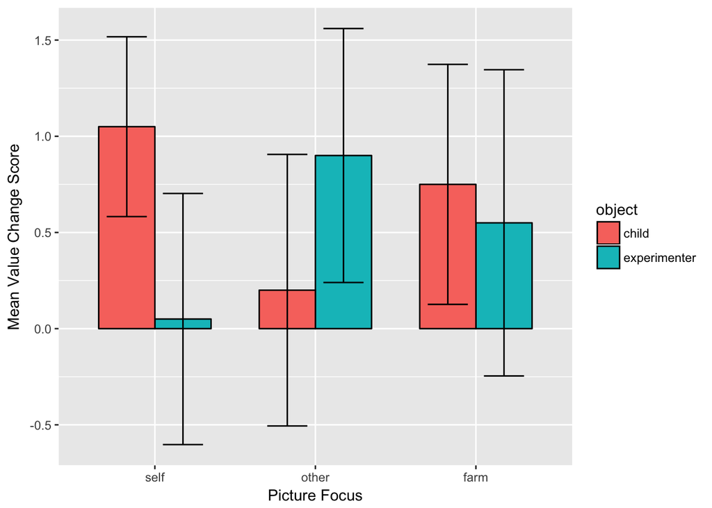

```r
df.object.prime_type.summary %>%
  filter(object != "neutral") %>%
  mutate(prime_type = factor(prime_type, levels = c("self", "other", "neutral"),
                             labels = c("self", "other", "farm"))) %>%
  ggplot(., aes( x = prime_type, fill = object, group = object,
                 y = sample_mean, ymin = ci_low, ymax = ci_high))+
  geom_col(position = position_dodge(0.7), width = 0.7, color = 'black')+
  geom_errorbar(position = position_dodge(0.7), width = 0.5)+
  ylab("Mean Value Change Score")+
  xlab("Picture Focus")
```

### Inferential statistics

Main results (Section 2.3):

```r
reported_inferentials <- list(
  anova = list(
    interaction = list(dfn = 2, dfd = 53, f = 4.83, p = 0.01),
    age = list(dfn = 1, dfd = 53, f = 7.68, p = 0.01),
    gender = list(dfn = 1, dfd = 53, f = 0.46, p = 0.50)
  ),
  ts = list(
    self_focus_child_experimenter = list(df = 19, t = 3.56, p = 0.01),
    other_focus_child_experimenter = list(df = 19, t = -1.61, p = 0.36),
    neutral_focus_child_experimenter = list(df = 19, t = 0.48, p = 0.64)
  )
)


# > To examine the effects of priming on value-change for the two identical endowment toys, a mixed ANCOVA was conducted. Toy owner (child or experimenter) was entered as a repeated measures factor and picture type (self-focus, other- focus, neutral-focus) and gender were entered as a between sub- jects factors. Additionally, child age was normalized and entered as a covariate into the model.

anova.rs <- ezANOVA(
  df.tidy %>%
    filter(scoringPeriod == "change", object != "neutral") %>%
    mutate(gender = factor(gender)),
  dv = response,
  wid = participant_id,
  within = .(object),
  between = .(prime_type, gender),
  between_covariates = age_normalized,
  detailed = T, return_aov = T
)

reportedValues_ownerPrimeInteraction = reported_inferentials$anova$interaction
obtainedValues_neutralPrimeInteraction = filter(anova.rs$ANOVA, Effect == "prime_type:object")

## df numerator
compareValues(
  reportedValues_ownerPrimeInteraction$dfn,
  obtainedValues_neutralPrimeInteraction$DFn
)
```

```
## [1] "MATCH. The reported value (2) and the obtained value (2) differed by 0%. NB obtained value was rounded to 0 decimal places."
```

```r
## df denominator
compareValues(
  reportedValues_ownerPrimeInteraction$dfd,
  obtainedValues_neutralPrimeInteraction$DFd
)
```

```
## [1] "MINOR NUMERICAL ERROR. The reported value (53) and the obtained value (54) differed by 1.89%. NB obtained value was rounded to 0 decimal places."
```

```r
## F stat
compareValues(
  reportedValues_ownerPrimeInteraction$f,
  obtainedValues_neutralPrimeInteraction$F
)
```

```
## [1] "MINOR NUMERICAL ERROR. The reported value (4.83) and the obtained value (4.87) differed by 0.83%. NB obtained value was rounded to 2 decimal places."
```

```r
## p-value
compareValues(
  reportedValues_ownerPrimeInteraction$p,
  obtainedValues_neutralPrimeInteraction$p,
  isP = T
)
```

```
## [1] "MATCH. The reported value (0.01) and the obtained value (0.01) differed by 0%. NB obtained value was rounded to 2 decimal places."
```

Main ANOVA results replicate, though numbers are off a bit.

```r
reportedValues_ts = reported_inferentials$ts

obtainedValues_selfFocus = with(df.tidy %>%
    filter(scoringPeriod == "change", object != "neutral", prime_type == "self") %>%
      spread(object, response),
    t.test(child, experimenter, paired = T))

obtainedValues_otherFocus = with(df.tidy %>%
    filter(scoringPeriod == "change", object != "neutral", prime_type == "other") %>%
      spread(object, response),
    t.test(child, experimenter, paired = T))

obtainedValues_neutralFocus = with(df.tidy %>%
    filter(scoringPeriod == "change", object != "neutral", prime_type == "neutral") %>%
      spread(object, response),
    t.test(child, experimenter, paired = T))


## T-TEST
### self-focus

compareValues(
  reportedValues_ts$self_focus_child_experimenter$df,
  obtainedValues_selfFocus$parameter
)
```

```
## [1] "MATCH. The reported value (19) and the obtained value (19) differed by 0%. NB obtained value was rounded to 0 decimal places."
```

```r
compareValues(
  reportedValues_ts$self_focus_child_experimenter$t,
  obtainedValues_selfFocus$statistic
)
```

```
## [1] "MATCH. The reported value (3.56) and the obtained value (3.56) differed by 0%. NB obtained value was rounded to 2 decimal places."
```

```r
compareValues(
  reportedValues_ts$self_focus_child_experimenter$p,
  obtainedValues_selfFocus$p.value, isP = T
)
```

```
## [1] "MAJOR NUMERICAL ERROR. The reported value (0.01) and the obtained value (0) differed by 100%. NB obtained value was rounded to 2 decimal places."
```

```r
### other-focus

compareValues(
  reportedValues_ts$other_focus_child_experimenter$df,
  obtainedValues_otherFocus$parameter
)
```

```
## [1] "MATCH. The reported value (19) and the obtained value (19) differed by 0%. NB obtained value was rounded to 0 decimal places."
```

```r
compareValues(
  reportedValues_ts$other_focus_child_experimenter$t,
  obtainedValues_otherFocus$statistic
)
```

```
## [1] "MATCH. The reported value (-1.61) and the obtained value (-1.61) differed by 0%. NB obtained value was rounded to 2 decimal places."
```

```r
compareValues(
  reportedValues_ts$other_focus_child_experimenter$p,
  obtainedValues_otherFocus$p.value, isP = T
)
```

```
## [1] "MAJOR NUMERICAL ERROR. The reported value (0.36) and the obtained value (0.12) differed by 66.67%. NB obtained value was rounded to 2 decimal places."
```

```r
### neutral-focus

compareValues(
  reportedValues_ts$neutral_focus_child_experimenter$df,
  obtainedValues_neutralFocus$parameter
)
```

```
## [1] "MATCH. The reported value (19) and the obtained value (19) differed by 0%. NB obtained value was rounded to 0 decimal places."
```

```r
compareValues(
  reportedValues_ts$neutral_focus_child_experimenter$t,
  obtainedValues_neutralFocus$statistic
)
```

```
## [1] "MATCH. The reported value (0.48) and the obtained value (0.48) differed by 0%. NB obtained value was rounded to 2 decimal places."
```

```r
compareValues(
  reportedValues_ts$neutral_focus_child_experimenter$p,
  obtainedValues_neutralFocus$p.value, isP = T
)
```

```
## [1] "MATCH. The reported value (0.64) and the obtained value (0.64) differed by 0%. NB obtained value was rounded to 2 decimal places."
```

No decision errors! It seems like the authors report all their p-values as p = 0.01 (when in fact they are < 0.01)

## Step 5: Conclusion

```r
codReport(Report_Type = 'pilot',
          Article_ID = 'JcuWB',
          Insufficient_Information_Errors = 0,
          Decision_Errors = 0,
          Major_Numerical_Errors = 23,
          Minor_Numerical_Errors = 6)
```

| Insufficient_Information_Errors | Decision_Errors | Major_Numerical_Errors | Minor_Numerical_Errors | Final_Outcome |
| --- | --- | --- | --- | --- |
| 0 | 0 | 23 | 6 | Failure |

I also am a little unclear on their reporting of their main ANCOVA. From their text, it seems like normalized age is a covariate (not a factor), but then they report an effect of age. I’m not a ANOVA expert, but when I run the `ezAnova` as I think makes sense, there is no estimate for age effect. So I’m not sure if I’m going wrong somewhere with that.

23 major numerical errors, but somehow, no decision errors.

[output not shown]

[output cut: 112 more lines]

[output not shown]